# Regression and Classification with AMES Housing Data

### Regression with the Ames Housing Data

#### Problem statement

You have just joined a new "full stack" real estate company in Ames, Iowa. The strategy of the firm is two-fold:

- Own the entire process from the purchase of the land all the way to sale of the house, and anything in between.
- Use statistical analysis to optimize investment and maximize return.

The company is still small, and though investment is substantial the short-term goals of the company are more oriented towards purchasing existing houses and flipping them as opposed to constructing entirely new houses. That being said, the company has access to a large construction workforce operating at rock-bottom prices.

This project uses the [Ames housing data recently made available on kaggle](https://www.kaggle.com/c/house-prices-advanced-regression-techniques).

```python
import numpy as np
import scipy.stats as stats
import seaborn as sns
import matplotlib.pyplot as plt
import pandas as pd

sns.set_style('whitegrid')

%config InlineBackend.figure_format = 'retina'
%matplotlib inline
```

[figure not shown]

## 1. Estimating the value of homes from fixed characteristics.

Your superiors have outlined this year's strategy for the company:

1. Develop an algorithm to reliably estimate the value of residential houses based on *fixed* characteristics.
2. Identify characteristics of houses that the company can cost-effectively change/renovate with their construction team.
3. Evaluate the mean dollar value of different renovations.

Then we can use that to buy houses that are likely to sell for more than the cost of the purchase plus renovations.

Your first job is to tackle #1. You have a dataset of housing sale data with a huge amount of features identifying different aspects of the house. The full description of the data features can be found in a separate file:

```
housing.csv
data_description.txt
```

You need to build a reliable estimator for the price of the house given characteristics of the house that cannot be renovated. Some examples include:

- The neighborhood
- Square feet
- Bedrooms, bathrooms
- Basement and garage space

and many more.

Some examples of things that **ARE renovate-able:**

- Roof and exterior features
- "Quality" metrics, such as kitchen quality
- "Condition" metrics, such as condition of garage
- Heating and electrical components

and generally anything you deem can be modified without having to undergo major construction on the house.

**Your goals:**

1. Perform any cleaning, feature engineering, and EDA you deem necessary.
- Be sure to remove any houses that are not residential from the dataset.
- Identify **fixed** features that can predict price.
- Train a model on pre-2010 data and evaluate its performance on the 2010 houses.
- Characterize your model. How well does it perform? What are the best estimates of price?

> **Note:** The EDA and feature engineering component to this project is not trivial! Be sure to always think critically and creatively. Justify your actions! Use the data description file!

```python
# Load the data
house = pd.read_csv('./housing.csv')
```

```python
# Check columns
house.columns
```

```
Index(['Id', 'MSSubClass', 'MSZoning', 'LotFrontage', 'LotArea', 'Street',
       'Alley', 'LotShape', 'LandContour', 'Utilities', 'LotConfig',
       'LandSlope', 'Neighborhood', 'Condition1', 'Condition2', 'BldgType',
       'HouseStyle', 'OverallQual', 'OverallCond', 'YearBuilt', 'YearRemodAdd',
       'RoofStyle', 'RoofMatl', 'Exterior1st', 'Exterior2nd', 'MasVnrType',
       'MasVnrArea', 'ExterQual', 'ExterCond', 'Foundation', 'BsmtQual',
       'BsmtCond', 'BsmtExposure', 'BsmtFinType1', 'BsmtFinSF1',
       'BsmtFinType2', 'BsmtFinSF2', 'BsmtUnfSF', 'TotalBsmtSF', 'Heating',
       'HeatingQC', 'CentralAir', 'Electrical', '1stFlrSF', '2ndFlrSF',
       'LowQualFinSF', 'GrLivArea', 'BsmtFullBath', 'BsmtHalfBath', 'FullBath',
       'HalfBath', 'BedroomAbvGr', 'KitchenAbvGr', 'KitchenQual',
       'TotRmsAbvGrd', 'Functional', 'Fireplaces', 'FireplaceQu', 'GarageType',
       'GarageYrBlt', 'GarageFinish', 'GarageCars', 'GarageArea', 'GarageQual',
       'GarageCond', 'PavedDrive', 'WoodDeckSF', 'OpenPorchSF',
       'EnclosedPorch', '3SsnPorch', 'ScreenPorch', 'PoolArea', 'PoolQC',
       'Fence', 'MiscFeature', 'MiscVal', 'MoSold', 'YrSold', 'SaleType',
       'SaleCondition', 'SalePrice'],
      dtype='object')
```

```python
# Check DataFrame
house.head()
```

|  | Id | MSSubClass | MSZoning | LotFrontage | LotArea | Street | Alley | LotShape | LandContour | Utilities | ... | PoolArea | PoolQC | Fence | MiscFeature | MiscVal | MoSold | YrSold | SaleType | SaleCondition | SalePrice |
| --- | --- | --- | --- | --- | --- | --- | --- | --- | --- | --- | --- | --- | --- | --- | --- | --- | --- | --- | --- | --- | --- |
| 0 | 1 | 60 | RL | 65.0 | 8450 | Pave | NaN | Reg | Lvl | AllPub | ... | 0 | NaN | NaN | NaN | 0 | 2 | 2008 | WD | Normal | 208500 |
| 1 | 2 | 20 | RL | 80.0 | 9600 | Pave | NaN | Reg | Lvl | AllPub | ... | 0 | NaN | NaN | NaN | 0 | 5 | 2007 | WD | Normal | 181500 |
| 2 | 3 | 60 | RL | 68.0 | 11250 | Pave | NaN | IR1 | Lvl | AllPub | ... | 0 | NaN | NaN | NaN | 0 | 9 | 2008 | WD | Normal | 223500 |
| 3 | 4 | 70 | RL | 60.0 | 9550 | Pave | NaN | IR1 | Lvl | AllPub | ... | 0 | NaN | NaN | NaN | 0 | 2 | 2006 | WD | Abnorml | 140000 |
| 4 | 5 | 60 | RL | 84.0 | 14260 | Pave | NaN | IR1 | Lvl | AllPub | ... | 0 | NaN | NaN | NaN | 0 | 12 | 2008 | WD | Normal | 250000 |

5 rows × 81 columns

```python
# Check Shape
house.shape
```

```
(1460, 81)
```

```python
# Check Datatypes
house.dtypes
```

```
Id                 int64
MSSubClass         int64
MSZoning          object
LotFrontage      float64
LotArea            int64
Street            object
Alley             object
LotShape          object
LandContour       object
Utilities         object
LotConfig         object
LandSlope         object
Neighborhood      object
Condition1        object
Condition2        object
BldgType          object
HouseStyle        object
OverallQual        int64
OverallCond        int64
YearBuilt          int64
YearRemodAdd       int64
RoofStyle         object
RoofMatl          object
Exterior1st       object
Exterior2nd       object
MasVnrType        object
MasVnrArea       float64
ExterQual         object
ExterCond         object
Foundation        object
                  ...
BedroomAbvGr       int64
KitchenAbvGr       int64
KitchenQual       object
TotRmsAbvGrd       int64
Functional        object
Fireplaces         int64
FireplaceQu       object
GarageType        object
GarageYrBlt      float64
GarageFinish      object
GarageCars         int64
GarageArea         int64
GarageQual        object
GarageCond        object
PavedDrive        object
WoodDeckSF         int64
OpenPorchSF        int64
EnclosedPorch      int64
3SsnPorch          int64
ScreenPorch        int64
PoolArea           int64
PoolQC            object
Fence             object
MiscFeature       object
MiscVal            int64
MoSold             int64
YrSold             int64
SaleType          object
SaleCondition     object
SalePrice          int64
Length: 81, dtype: object
```

```python
# Check for nulls
house.isnull().sum()
```

```
Id                  0
MSSubClass          0
MSZoning            0
LotFrontage       259
LotArea             0
Street              0
Alley            1369
LotShape            0
LandContour         0
Utilities           0
LotConfig           0
LandSlope           0
Neighborhood        0
Condition1          0
Condition2          0
BldgType            0
HouseStyle          0
OverallQual         0
OverallCond         0
YearBuilt           0
YearRemodAdd        0
RoofStyle           0
RoofMatl            0
Exterior1st         0
Exterior2nd         0
MasVnrType          8
MasVnrArea          8
ExterQual           0
ExterCond           0
Foundation          0
                 ...
BedroomAbvGr        0
KitchenAbvGr        0
KitchenQual         0
TotRmsAbvGrd        0
Functional          0
Fireplaces          0
FireplaceQu       690
GarageType         81
GarageYrBlt        81
GarageFinish       81
GarageCars          0
GarageArea          0
GarageQual         81
GarageCond         81
PavedDrive          0
WoodDeckSF          0
OpenPorchSF         0
EnclosedPorch       0
3SsnPorch           0
ScreenPorch         0
PoolArea            0
PoolQC           1453
Fence            1179
MiscFeature      1406
MiscVal             0
MoSold              0
YrSold              0
SaleType            0
SaleCondition       0
SalePrice           0
Length: 81, dtype: int64
```

```python
# Check values for MSZoning non residential properties
house['MSZoning'].value_counts()
```

```
RL         1151
RM          218
FV           65
RH           16
C (all)      10
Name: MSZoning, dtype: int64
```

```python
# Remove non residential properties as per instructions
house.drop(house.loc[house['MSZoning'] == 'C (all)'].index, inplace=True)
```

```python
house['MSZoning'].value_counts()
```

```
RL    1151
RM     218
FV      65
RH      16
Name: MSZoning, dtype: int64
```

```python
# Identify fixed features:

# MSSubClass: Identifies the type of dwelling involved in the sale.
# MSZoning: Identifies the general zoning classification of the sale.
# Neighborhood: Physical locations within Ames city limits
# LotFrontage: Linear feet of street connected to property
# LotArea: Lot size in square feet
# HouseStyle: Style of dwelling
# LotShape: General shape of property
# LandContour: Flatness of the property
# LotConfig: Lot configuration
# LandSlope: Slope of property
# Condition1: Proximity to various conditions
# Condition2: Proximity to various conditions (if more than one is present)
# YearBuilt: Original construction date
# BldgType: Type of dwelling
# HouseStyle: Style of dwelling
# Foundation: Type of foundation
# TotalBsmtSF: Total square feet of basement area
# BsmtQual: Evaluates the height of the basement
# BsmtExposure: Refers to walkout or garden level walls
# 1stFlrSF: First Floor square feet
# 2ndFlrSF: Second floor square feet
# BsmtFullBath: Basement full bathrooms
# BsmtHalfBath: Basement half bathrooms
# FullBath: Full bathrooms above grade
# HalfBath: Half baths above grade
# Bedroom: Bedrooms above grade (does NOT include basement bedrooms)
# Kitchen: Kitchens above grade
# TotRmsAbvGrd: Total rooms above grade (does not include bathrooms)
# Fireplaces: Number of fireplaces
# GarageType: Garage location
# GarageCars: Size of garage in car capacity
# GarageArea: Size of garage in square feet
# WoodDeckSF: Wood deck area in square feet
# OpenPorchSF: Open porch area in square feet
# EnclosedPorch: Enclosed porch area in square feet
# 3SsnPorch: Three season porch area in square feet
# ScreenPorch: Screen porch area in square feet
# PoolArea: Pool area in square feet
```

```python
fixed_df = pd.DataFrame(house[['SalePrice','MSSubClass',
'MSZoning',''
'Neighborhood',
'LotFrontage',
'LotArea',
'Street',
'LotShape',
'LandContour',
'LotConfig',
'LandSlope',
'Condition1',
'Condition2',
'YearBuilt',
'BldgType',
'HouseStyle',
'Foundation',
'TotalBsmtSF',
'BsmtQual',
'BsmtExposure',
'1stFlrSF',
'2ndFlrSF',
'GrLivArea',
'BsmtFullBath',
'BsmtHalfBath',
'FullBath',
'HalfBath',
'BedroomAbvGr',
'KitchenAbvGr',
'TotRmsAbvGrd',
'Fireplaces',
'GarageType',
'GarageCars',
'GarageArea',
'WoodDeckSF',
'OpenPorchSF',
'EnclosedPorch',
'3SsnPorch',
'ScreenPorch',
'PoolArea',
'YrSold']])
```

```python
fixed_df.shape
```

```
(1450, 41)
```

```python
fixed_df.isnull().sum()
```

```
SalePrice          0
MSSubClass         0
MSZoning           0
Neighborhood       0
LotFrontage      259
LotArea            0
Street             0
LotShape           0
LandContour        0
LotConfig          0
LandSlope          0
Condition1         0
Condition2         0
YearBuilt          0
BldgType           0
HouseStyle         0
Foundation         0
TotalBsmtSF        0
BsmtQual          37
BsmtExposure      38
1stFlrSF           0
2ndFlrSF           0
GrLivArea          0
BsmtFullBath       0
BsmtHalfBath       0
FullBath           0
HalfBath           0
BedroomAbvGr       0
KitchenAbvGr       0
TotRmsAbvGrd       0
Fireplaces         0
GarageType        79
GarageCars         0
GarageArea         0
WoodDeckSF         0
OpenPorchSF        0
EnclosedPorch      0
3SsnPorch          0
ScreenPorch        0
PoolArea           0
YrSold             0
dtype: int64
```

```python
# Fill or drop nulls

#Impute the median for LotFrontage
median_LotFrontage = fixed_df['LotFrontage'].median() #LotFrontage showed a normal distribution where the mean & median are the same
fixed_df['LotFrontage'] = fixed_df['LotFrontage'].fillna(median_LotFrontage)

# Fill null values of BsmtQual with 'NA'. I am assuming NA means No Basement
fixed_df['BsmtQual'] = fixed_df['BsmtQual'].fillna('NA')

# Fill null values of BsmtExposure with 'NA'. I am assuming NA means No Basement
fixed_df['BsmtExposure'] = fixed_df['BsmtExposure'].fillna('NA')

#Fill null values of GarageType with 'NA'. I am assuming NA means No Garage, as per data dictionary
fixed_df['GarageType'] = fixed_df['GarageType'].fillna('NA')
```

```python
# Check for count unique values for each column
for item in fixed_df:
    print(item, fixed_df[item].nunique())
```

```
SalePrice 657
MSSubClass 15
MSZoning 4
Neighborhood 25
LotFrontage 110
LotArea 1070
Street 2
LotShape 4
LandContour 4
LotConfig 5
LandSlope 3
Condition1 9
Condition2 8
YearBuilt 112
BldgType 5
HouseStyle 8
Foundation 6
TotalBsmtSF 719
BsmtQual 5
BsmtExposure 5
1stFlrSF 746
2ndFlrSF 413
GrLivArea 858
BsmtFullBath 4
BsmtHalfBath 3
FullBath 4
HalfBath 3
BedroomAbvGr 8
KitchenAbvGr 4
TotRmsAbvGrd 12
Fireplaces 4
GarageType 7
GarageCars 5
GarageArea 440
WoodDeckSF 273
OpenPorchSF 201
EnclosedPorch 118
3SsnPorch 20
ScreenPorch 75
PoolArea 8
YrSold 5
```

```python
# Inspect the SalePrice

print(fixed_df['SalePrice'].describe())
print(fixed_df['SalePrice'].median())
```

```
count      1450.000000
mean     181654.942069
std       79176.485241
min       37900.000000
25%      130000.000000
50%      163945.000000
75%      214000.000000
max      755000.000000
Name: SalePrice, dtype: float64
163945.0
```

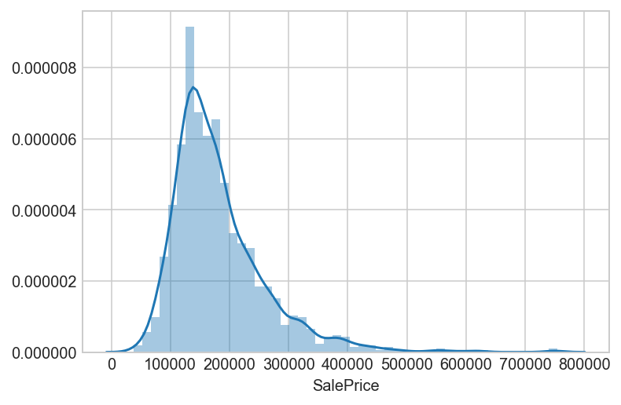

```python
# Plot the SalePrice distribution

sns.distplot(fixed_df['SalePrice'])
```

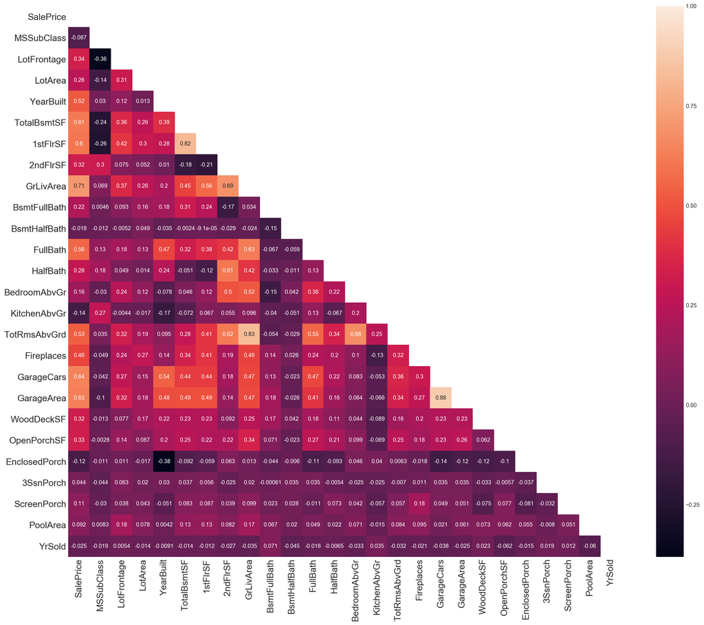

```python
# Inspect correlation between variables

def correlation_heat_map(df):
    corrs = fixed_df.corr()

    fig, ax = plt.subplots(figsize=(22,18))

    mask = np.zeros_like(corrs, dtype=np.bool)
    mask[np.triu_indices_from(mask)] = True

    ax = sns.heatmap(corrs, mask=mask, annot=True)

    ax.set_xticklabels(ax.xaxis.get_ticklabels(), fontsize=16, rotation=90)
    ax.set_yticklabels(ax.yaxis.get_ticklabels(), fontsize=16, rotation=0)


    plt.show()

correlation_heat_map(fixed_df)
```

```python
corrs = fixed_df.corr()
```

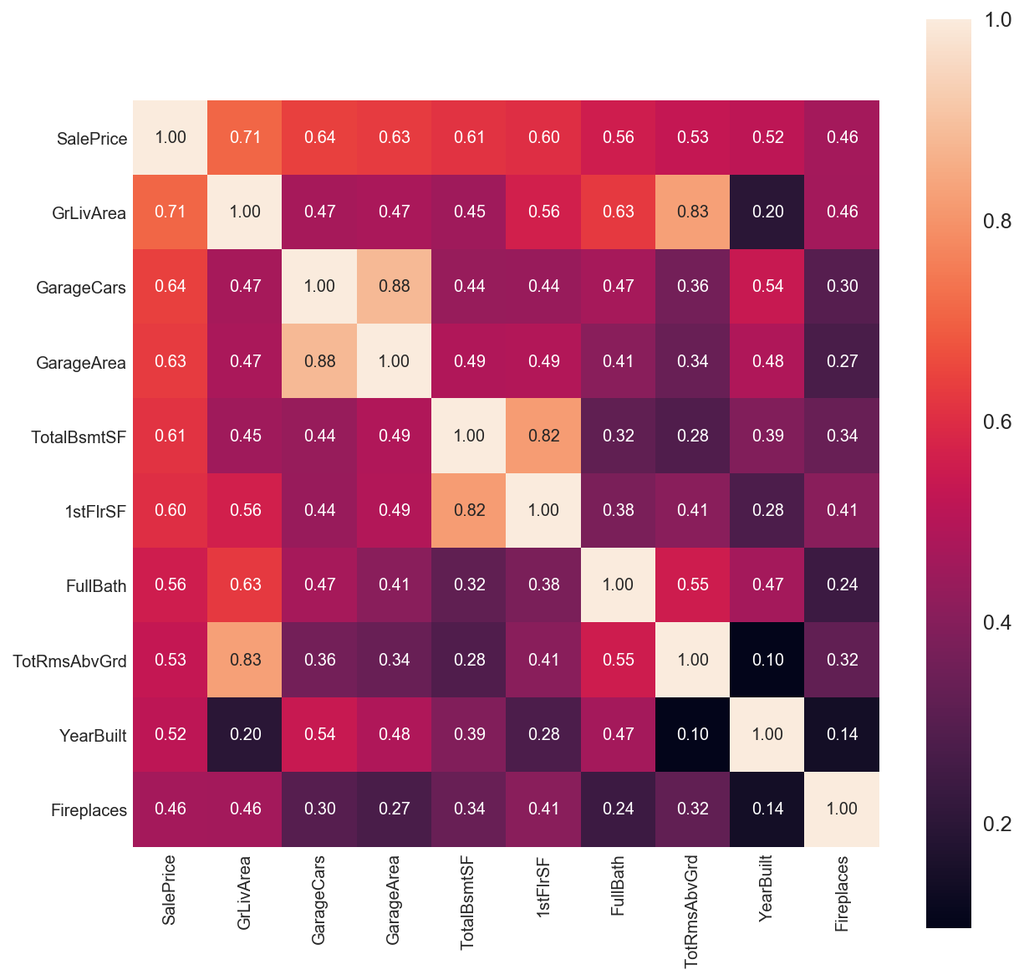

```python
# Plot variables with highest correlation with SalePrice

k = 10 #number of variables for heatmap
cols = corrs.nlargest(k, 'SalePrice')['SalePrice'].index
cm = np.corrcoef(fixed_df[cols].values.T)
fig, ax = plt.subplots(figsize=(10,10))
sns.set(font_scale=1.25)
hm = sns.heatmap(cm, cbar=True, annot=True, square=True, fmt='.2f', annot_kws={'size': 10}, yticklabels=cols.values, xticklabels=cols.values)

plt.show()
```

```python
# Sort variables by correlation coefficient descending
c1 = corrs.abs().unstack()
c1.SalePrice.sort_values(ascending = False)
```

```
SalePrice        1.000000
GrLivArea        0.708658
GarageCars       0.642135
GarageArea       0.629831
TotalBsmtSF      0.612088
1stFlrSF         0.603300
FullBath         0.556674
TotRmsAbvGrd     0.533355
YearBuilt        0.517602
Fireplaces       0.463264
LotFrontage      0.337567
OpenPorchSF      0.329491
WoodDeckSF       0.320770
2ndFlrSF         0.319774
HalfBath         0.280882
LotArea          0.264715
BsmtFullBath     0.224054
BedroomAbvGr     0.162008
KitchenAbvGr     0.137825
EnclosedPorch    0.120765
ScreenPorch      0.110540
PoolArea         0.092396
MSSubClass       0.087487
3SsnPorch        0.043807
YrSold           0.025391
BsmtHalfBath     0.017561
dtype: float64
```

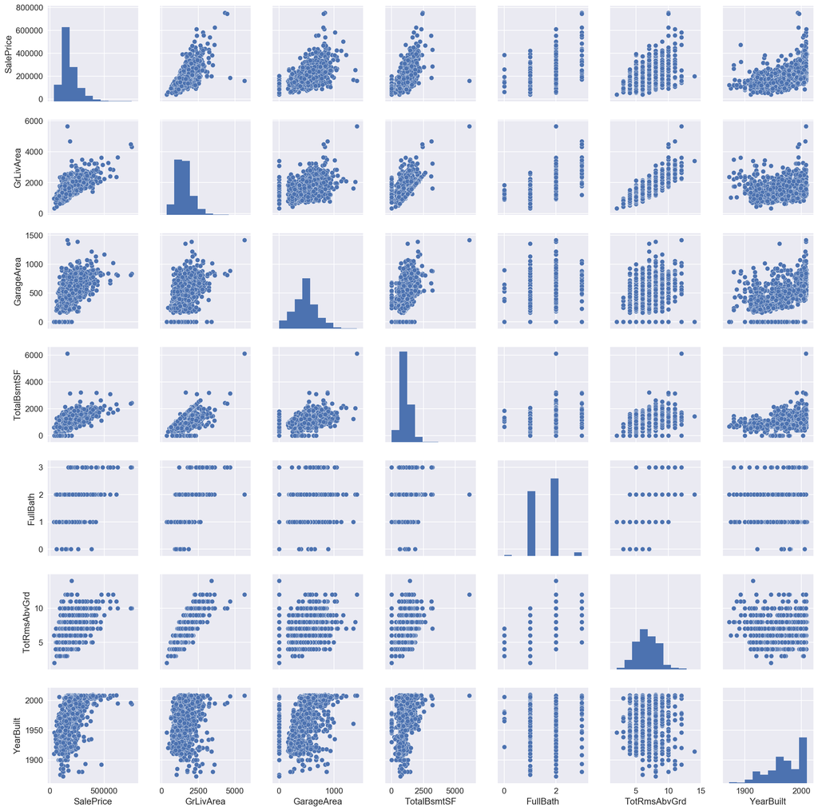

```python
# Check if there is a linear relationship between SalePrice and the variables GrLivArea, GarageArea, TotalBsmtSF, FullBath,TotRmsAbvGrd, YrSold

corr_df = pd.DataFrame(fixed_df[["SalePrice","GrLivArea","GarageArea","TotalBsmtSF","FullBath","TotRmsAbvGrd","YearBuilt"]])
sns.pairplot(corr_df, hue=None, hue_order=None, palette=None, vars=["SalePrice","GrLivArea","GarageArea","TotalBsmtSF","FullBath","TotRmsAbvGrd","YearBuilt"], x_vars=None, y_vars=None, markers=None, size=2.5, aspect=1, dropna=True, plot_kws=None, diag_kws=None, grid_kws=None)
```